# Week5

Jessica Brown

2023-09-12

```r
#Set up for incoming code
library(readr)
library(ggplot2)
library(forecast)
library(fpp2)
library(TTR)
library(dplyr)
library(lubridate)
library(here)
library(prophet)
library(tsfknn)
library(usethis)
library(devtools)

data = read.csv(here("Datasets", "Police_Department_Incident_Reports__2018_to_Present.csv"))

#not using 2023 & analyzing missing person only
data = data.frame(subset(data, Incident.Year != 2023 &
Incident.Category == "Missing Person" & Report.Type.Code == "II"))

#Lubridate datetime columns
data$Incident.Datetime = parse_date_time(data$Incident.Datetime,
orders = "mdy HM")
data$Incident.Date = parse_date_time(data$Incident.Date,
orders = "mdy")

#Make a column for month & store month value for every column
data$Incident.Month = 0 ; i = 0; j = length(data$Incident.Date)
while(i <= j){
  data$Incident.Month[i] = month(data$Incident.Date[i])
  i = i + 1
}
rm(i)
rm(j)

#Now, only get data for given year
data_2022 = data.frame(subset(data, Incident.Year == 2022))

#Count how many incidents per month for given year
data_2022 = data.frame(table(data_2022$Incident.Month))


#Do for all years
data_2021 = data.frame(subset(data, Incident.Year == 2021))
data_2020 = data.frame(subset(data, Incident.Year == 2020))
data_2019 = data.frame(subset(data, Incident.Year == 2019))
data_2018 = data.frame(subset(data, Incident.Year == 2018))

data_2021 = data.frame(table(data_2021$Incident.Month))
data_2020 = data.frame(table(data_2020$Incident.Month))
data_2019 = data.frame(table(data_2019$Incident.Month))
data_2018 = data.frame(table(data_2018$Incident.Month))

#Combine all year's month count data into one df
data_months_vertical = rbind(data_2018, data_2019, data_2020, data_2021)
data_months_vertical = data.frame(data_months_vertical$Freq)

#Rename col for later shenanigans
colnames(data_months_vertical) = c("Freq")

#Remove separate datasets from environment (except 2022 because that's test data)
rm(data_2021)
rm(data_2020)
rm(data_2018)

#Make a Time-Series w/ 2018-2022
data_ts = ts(data_months_vertical, frequency = 12, start = c(2018, 1))
data_ts
```

```
##      Jan Feb Mar Apr May Jun Jul Aug Sep Oct Nov Dec
## 2018 182 184 194 188 199 216 160 179 171 204 181 166
## 2019 174 151 174 190 172 190 191 192 189 179 141 182
## 2020 154 163 192 113 132 154 146 134 126 128 142 135
## 2021 117 100 128 115 120 143 142 159 140 144 142 155
```

```r
#Plot Time-Series
plot.ts(data_ts)
```

[output not shown]

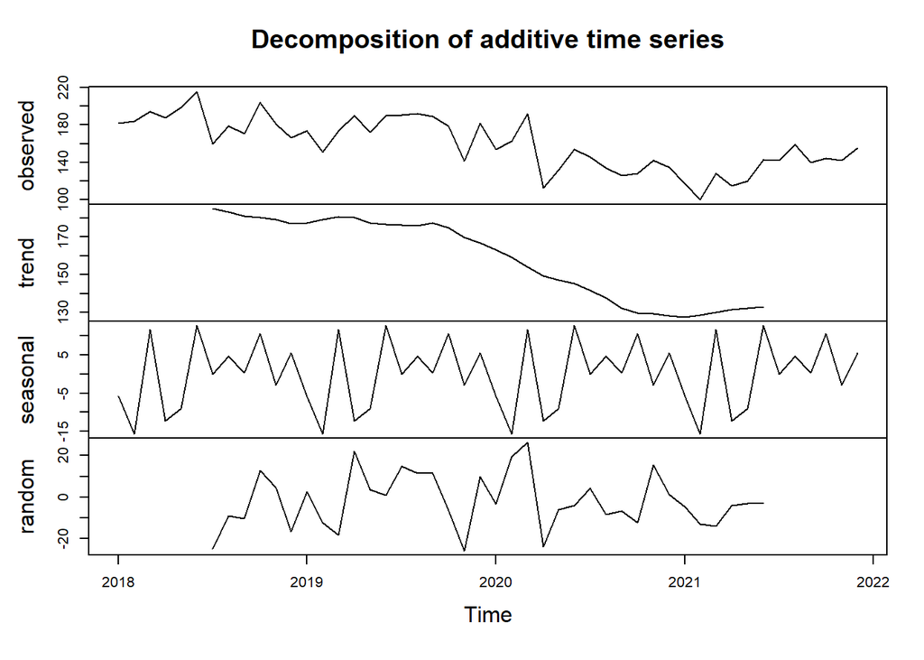

```r
#Plot inididual components of time-series (random, seasonal, trend, observed)
data_ts_components = decompose(data_ts)
plot(data_ts_components)
```

Above is a time-series that R provides without any type of predictive modelling. We are going to be using predictive models to predict or forecast data for 2022 from 2018-2021 data.

First, I will display the actual 2022 time-series data so the below models can be compared to the actuality. Whichever model is closest shows what type of model is the best predictor for this data set.

```r
data_2022 = data.frame(data_2022$Freq)
colnames(data_2022) = c("Freq")
data_2022 = rbind(data_months_vertical, data_2022)
data_2022_ts = ts(data_2022, frequency = 12, start = c(2018, 1))
data_2022_ts
```

```
##      Jan Feb Mar Apr May Jun Jul Aug Sep Oct Nov Dec
## 2018 182 184 194 188 199 216 160 179 171 204 181 166
## 2019 174 151 174 190 172 190 191 192 189 179 141 182
## 2020 154 163 192 113 132 154 146 134 126 128 142 135
## 2021 117 100 128 115 120 143 142 159 140 144 142 155
## 2022 128 119 163 148 159 137 148 182 169 172 145 151
```

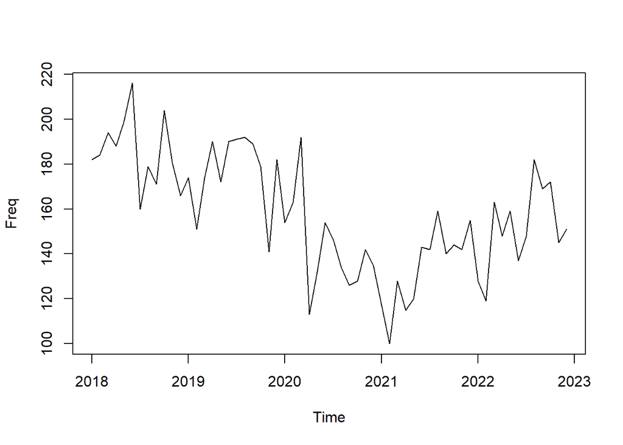

```r
plot.ts(data_2022_ts)
```

Now, the first time-series model to be used will be Simple Exponential Smoothing.

```r
#Apparently,  "simple exponential smoothing" only uses alpha so you set beta & gamma to false
data_ts_expsmth = HoltWinters(data_ts, beta = F, gamma = F)

#Display alpha
data_ts_expsmth
```

```
## Holt-Winters exponential smoothing without trend and without seasonal component.
##
## Call:
## HoltWinters(x = data_ts, beta = F, gamma = F)
##
## Smoothing parameters:
##  alpha: 0.3610213
##  beta : FALSE
##  gamma: FALSE
##
## Coefficients:
##       [,1]
## a 146.8761
```

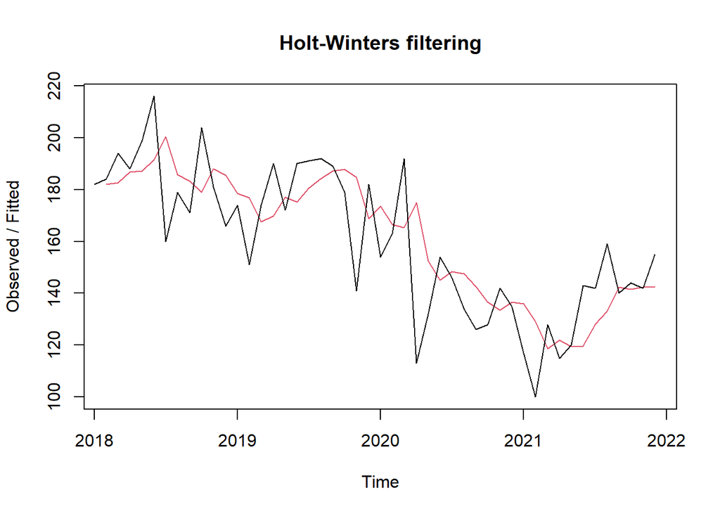

```r
#Display Exp Smoothing Plot
plot(data_ts_expsmth)
```

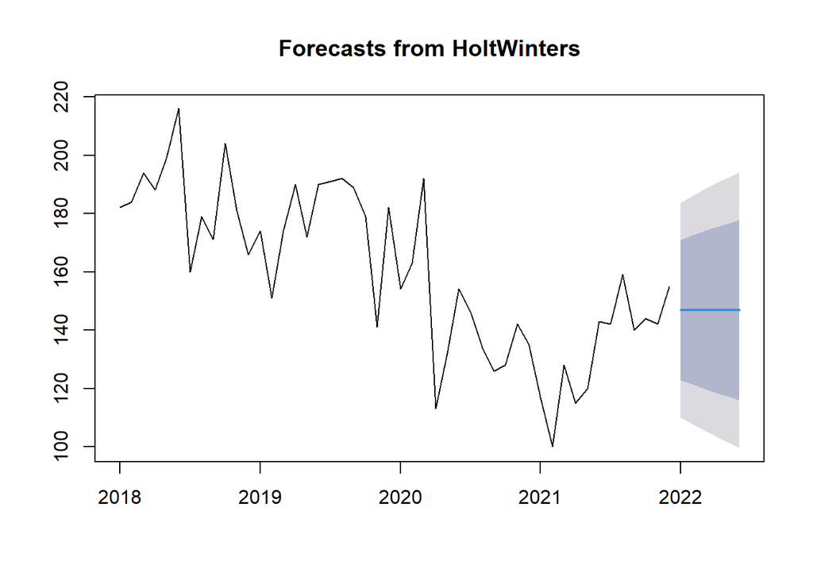

```r
plot(forecast(data_ts_expsmth, h = 6))
```

```r
#Actual datapoints
fore_expxmth = data.frame(forecast(data_ts_expsmth, h = 6))
```

```r
#Holt's Exponential Smoothing uses beta and alpha
data_ts_holt_expsmth = HoltWinters(data_ts, gamma = F)

#Display all Holt-Winters information
data_ts_holt_expsmth
```

```
## Holt-Winters exponential smoothing with trend and without seasonal component.
##
## Call:
## HoltWinters(x = data_ts, gamma = F)
##
## Smoothing parameters:
##  alpha: 0.3978042
##  beta : 0.06033842
##  gamma: FALSE
##
## Coefficients:
##          [,1]
## a 147.0139988
## b   0.1523839
```

Here is Holt’s exponential smoothing. The difference between this type and Simple Exponential Smoothing is that the latter uses only alpha while the former uses both alpha and beta.

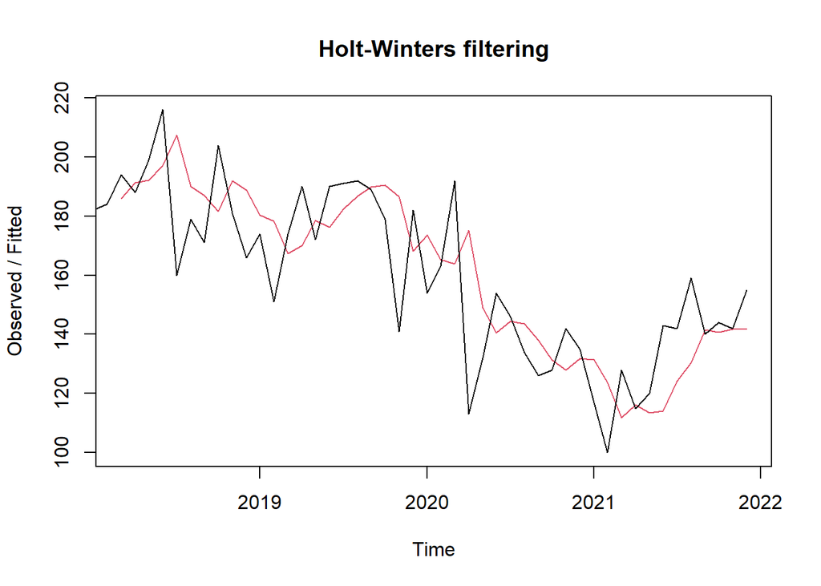

```r
#Plot Holt Winter's Exp Smoothing
plot(data_ts_holt_expsmth)
```

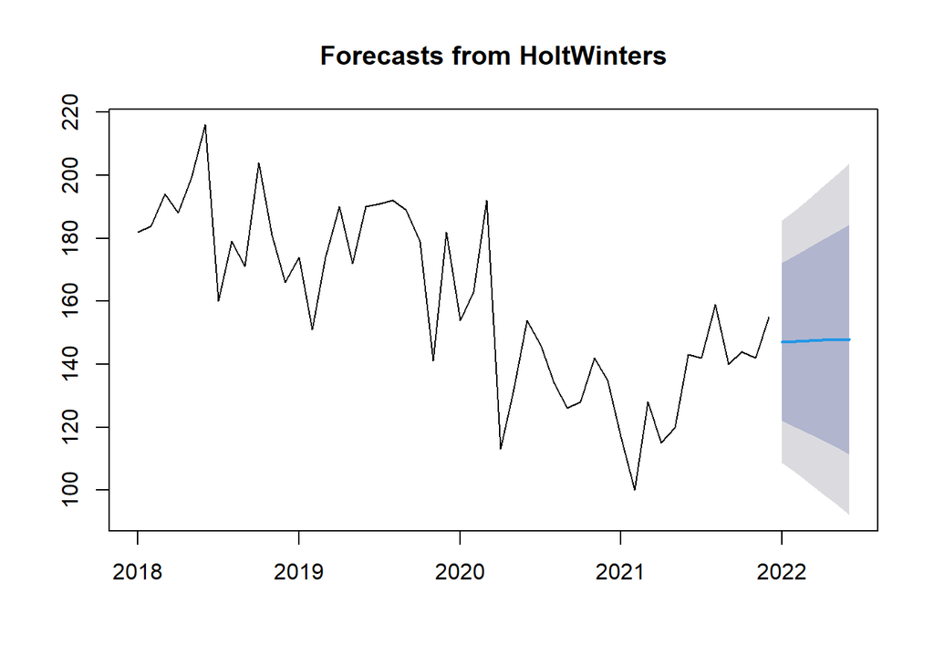

```r
plot(forecast(data_ts_holt_expsmth, h = 6))
```

```r
#Get Actual Datapoints
fore_holtexpxmth = data.frame(forecast(data_ts_holt_expsmth, h = 6))
```

Now, we will do ARIMA modelling. To do ARIMA modelling, you have to acheive a stationary mean, meaning that the mean does not fluctuate much overtime. The way you do this is through the diff() function. You increase the number in the differences parameter until the mean looks “stationary”

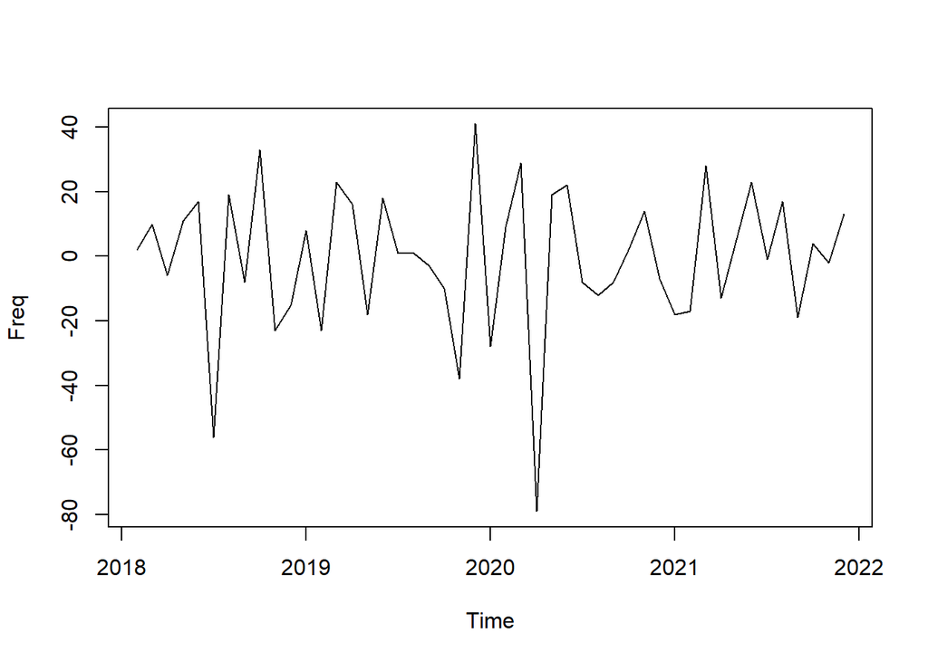

```r
data_ts_arima = diff(data_ts, differences = 1)
plot(data_ts_arima)
```

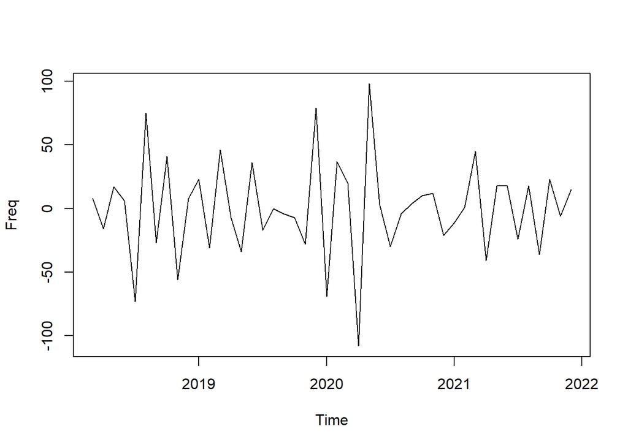

```r
data_ts_arima = diff(data_ts, differences = 2)
plot(data_ts_arima)
```

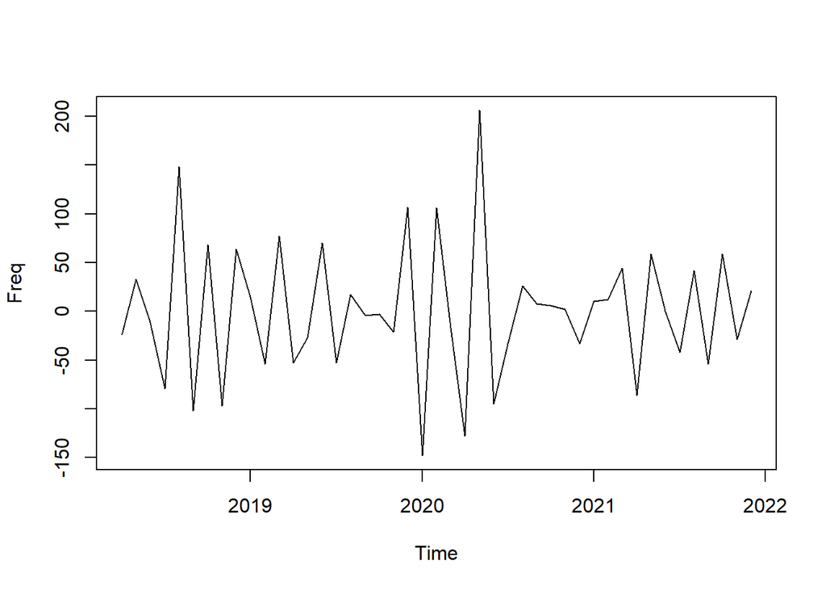

```r
data_ts_arima = diff(data_ts, differences = 3)
plot(data_ts_arima)
```

```r
d = 3

#At 3 differences, as you can see in the output, it has a pretty decent stationary mean
```

The ARIMA model uses 3 values ARIMA(p, d, q). We have already found d which is the number of difference. In our case, this is 3. Now, we must find the values of p & q.

To get q, we have to use a correlogram WITH the DIFFERENCES Time-Series.

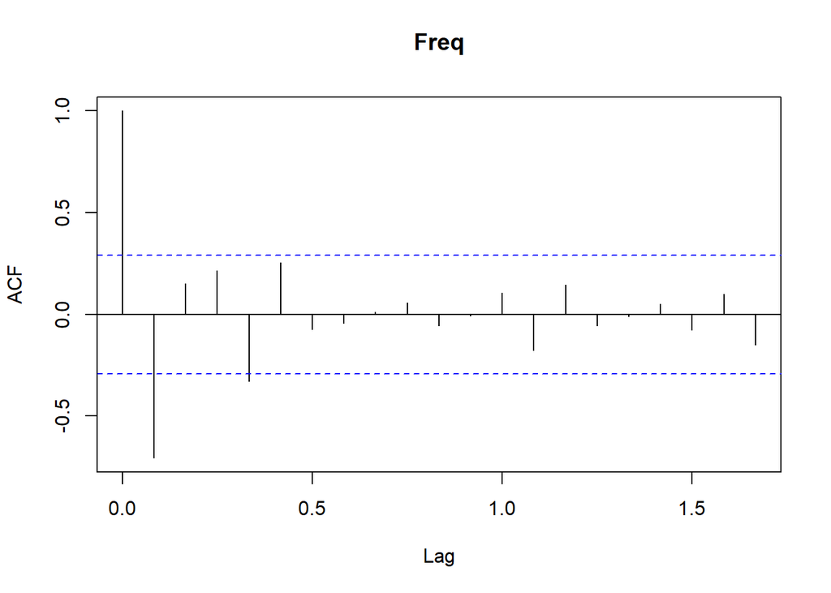

```r
acf(data_ts_arima, lag.max = 20)
```

```r
acf(data_ts_arima, lag.max = 20, plot = F)
```

```
##
## Autocorrelations of series 'data_ts_arima', by lag
##
## 0.0000 0.0833 0.1667 0.2500 0.3333 0.4167 0.5000 0.5833 0.6667 0.7500 0.8333
##  1.000 -0.706  0.152  0.215 -0.328  0.253 -0.074 -0.042  0.010  0.058 -0.056
## 0.9167 1.0000 1.0833 1.1667 1.2500 1.3333 1.4167 1.5000 1.5833 1.6667
## -0.008  0.106 -0.176  0.145 -0.056 -0.010  0.051 -0.077  0.099 -0.151
```

```r
q = 2
```

Now to find p, we do the same thing but with a partial correlogram.

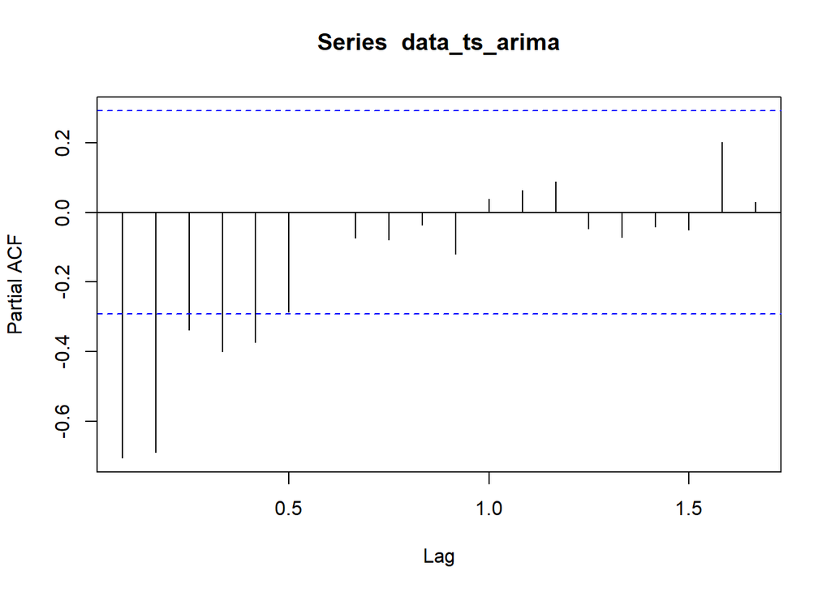

```r
pacf(data_ts_arima, lag.max = 20)
```

```r
pacf(data_ts_arima, lag.max = 20, plot = F)
```

```
##
## Partial autocorrelations of series 'data_ts_arima', by lag
##
## 0.0833 0.1667 0.2500 0.3333 0.4167 0.5000 0.5833 0.6667 0.7500 0.8333 0.9167
## -0.706 -0.689 -0.337 -0.399 -0.372 -0.287  0.001 -0.073 -0.078 -0.036 -0.119
## 1.0000 1.0833 1.1667 1.2500 1.3333 1.4167 1.5000 1.5833 1.6667
##  0.039  0.064  0.089 -0.047 -0.072 -0.041 -0.049  0.202  0.031
```

```r
p = 5
```

This plot shows that after 5, the lag tails off to 0 therfore p = 5.

To specifically use the ARIMA auto regressive model, you’d plot ARIMA(p, 0). The moving average is ARIMA(0, q). Lastly, the ARIMA mixed model which uses both auto regression and a moving average will be plotted with ARIMA(p, q). We have no reason to use the specific models, so we are using the mixed model.

```r
fit = Arima(data_ts, order = c(p, d, q))
plot(fit$x)
```

[output not shown]

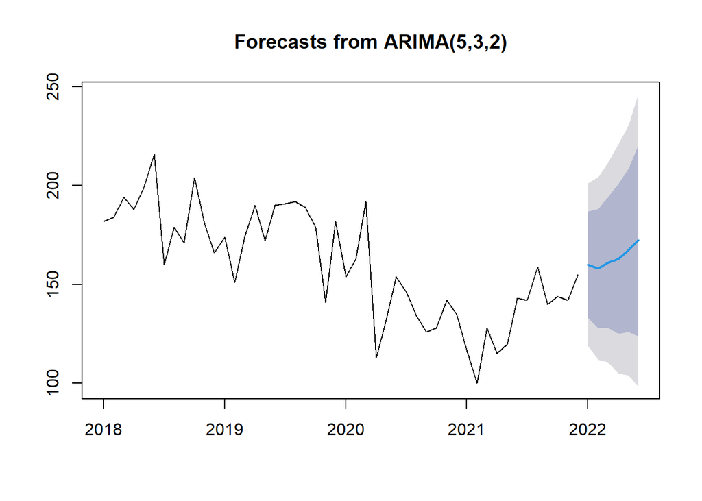

```r
plot(forecast(fit, h = 6))
```

```r
#Get actual datapoints
fore_arimamine = data.frame(forecast(fit, h = 6))
```

This function tells you the ARIMA model you should use without all the extra work, but it gave me something completely else…

```r
auto.arima(data_ts)
```

```
## Series: data_ts
## ARIMA(0,1,1)
##
## Coefficients:
##           ma1
##       -0.6299
## s.e.   0.1055
##
## sigma^2 = 356.8:  log likelihood = -204.55
## AIC=413.11   AICc=413.38   BIC=416.81
```

```r
fit2 = Arima(data_ts, order = c(0, 1, 1))
plot(fit2$x)
```

[output not shown]

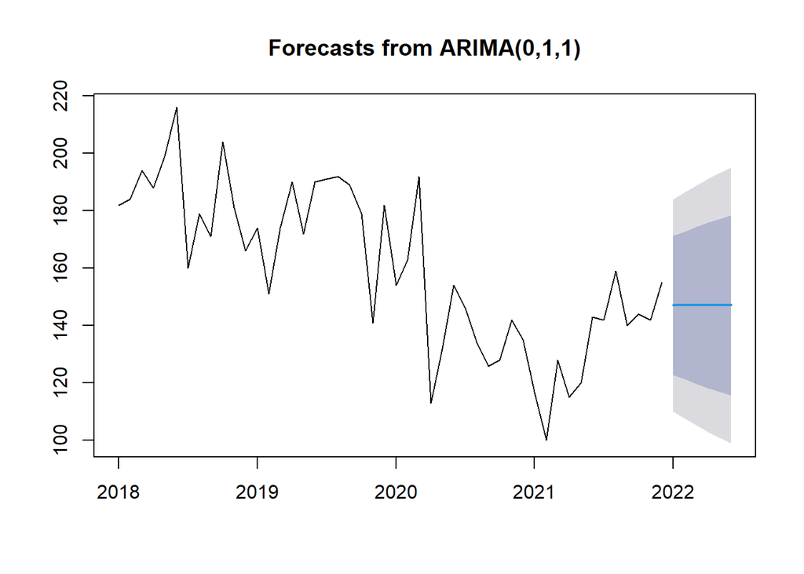

```r
plot(forecast(fit2, h = 6))
```

```r
#Get Actual Datapoints
fore_arimaauto = data.frame(forecast(fit2, h = 6))
```

```r
#Doing some cleanup of unneeded variables
#rm(d)
#rm(q)
#rm(p)
#rm(data_ts_arima)
#rm(data_ts)
#rm(data_2022_ts)
#rm(fit)
#rm(fit2)
#rm(data_ts_components)
#rm(data_ts_expsmth)
#rm(data_ts_holt_expsmth)
```

```r
#Prophet requires a different dataframe structure, so we must restructure our initial dataframe that was used for all above predictions. It needs an additional column that holds date information

prophet_df = data.frame(subset(data, data$Incident.Year < 2022))
prophet_df = data.frame(prophet_df$Incident.Date)
prophet_df = data.frame(table(prophet_df$prophet_df.Incident.Date))

#Very specifically, this model demands a column called ds (datetime) and y (values) so rename the columns
colnames(prophet_df) = c("ds", "y")

#All of these are propher built in functions. I don't fully understand these. I read a tutorial to do this.
prophet_df_ts = prophet(prophet_df)
```

```
## Disabling daily seasonality. Run prophet with daily.seasonality=TRUE to override this.
```